# 第4回 データの可視化（2）：グラフのカスタマイズと保存

行動計量学（行動科学分析法入門）

小野原 彩香

令和8年度

## 本日の目標

1. `theme()` を使ってグラフの見た目を整える
2. グラフを論文・レポート向けに整形できる
3. グラフをファイルに保存できる（`ggsave()`）

## 0. 前回の復習：2週間ぶりです

10月23日は休講だったので，第3回（10月16日）から2週間空いています。 今日やるのは**第3回で作ったグラフをきれいにする**ことなので， まず前回の宿題のファイルが動くことを確認してください。

### 0-1. 宿題のファイルを開いて実行する

1. RStudioを起動する
2. 前回保存した `.R` ファイルを開く（`File` → `Open File...`）
3. **全選択（`Ctrl + A`）してから `Ctrl + Enter`**（Mac は `Cmd + A` → `Cmd + Enter`）で， まとめて実行する
4. **散布図・ヒストグラム・箱ひげ図の3つが表示されれば完了です** （図は Plots タブの左右の矢印でさかのぼれます）

> **うまくいかないときは**
> - **「関数 ‘ggplot’ を見つけることができませんでした」というエラー** → `library(tidyverse)` の行が実行されていません。全選択して実行し直してください。 なお `iris` はR本体に入っているデータなので，これは読み込まなくても使えます
> - **ファイルがどこにあるか分からない** → 作り直しても構いません。 **第3回 演習の模範解答（`.R` ファイル）** をそのまま使って構いません。 問題から解き直したい人は第3回の演習にあります。 保存先の決め方は第3回の0-1を見てください
> - **コードは走るのに図が出ない** → `source("ファイル名.R")` や `Source` ボタンで 実行していませんか。この方法では図が表示されません。 **全選択して `Ctrl + Enter`** で実行してください
> - **どこで失敗しているのか分からない** → そのときだけ，1行目にカーソルを置いて `Ctrl + Enter` を繰り返し，止まる行を探してください。 **ふだんは全選択で構いません**

### 0-2. 今日のために思い出しておくこと

今日は新しいグラフの種類は出てきません。**第3回の書き方の `+` の後ろに，見た目の指定を足していく**だけです。

| 第3回で学んだこと | 今日の使い方 |
| --- | --- |
| `ggplot(data = ..., aes(...)) + geom_xxx()` | この後ろに `+ theme_bw()` などを足す |
| `aes()` の中は「データを見た目に対応づける」 | `aes(color = Species)` で分かれた色を，今日は自分で選ぶ |
| `labs()` でタイトル・軸ラベルを付ける | 今日も使います。日本語のラベルを付けます |

上の3点が思い出せていれば大丈夫です。では始めましょう。

## 準備：パッケージの読み込み

この回のコードは，すべて `tidyverse` を読み込んだ状態で動きます。 RStudioを起動したら，**まずこれを実行してください。**

```r
library(tidyverse)
```

> 毎回必要です。読み込まないまま `ggplot()` を使うと， 「関数 ‘ggplot’ を見つけることができませんでした」というエラーになります。

## 1. テーマ（theme）によるデザイン変更

ggplot2には，グラフ全体の見た目を変える**テーマ**が用意されています。

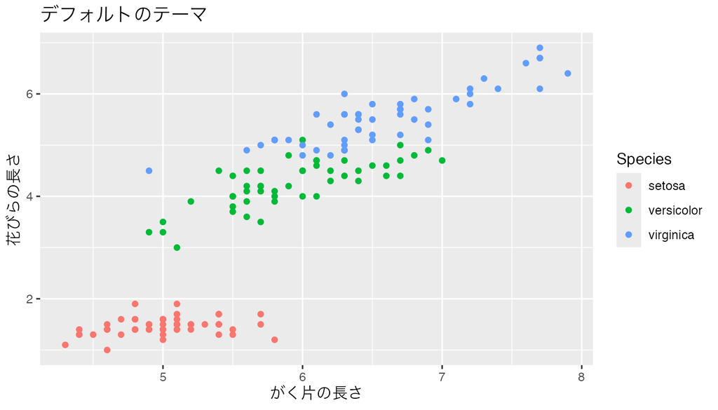

```r
# デフォルトのグラフ
p <- ggplot(data = iris, aes(x = Sepal.Length, y = Petal.Length, color = Species)) +
  geom_point() +
  labs(title = "デフォルトのテーマ", x = "がく片の長さ", y = "花びらの長さ")
p
```

### 主なテーマ一覧

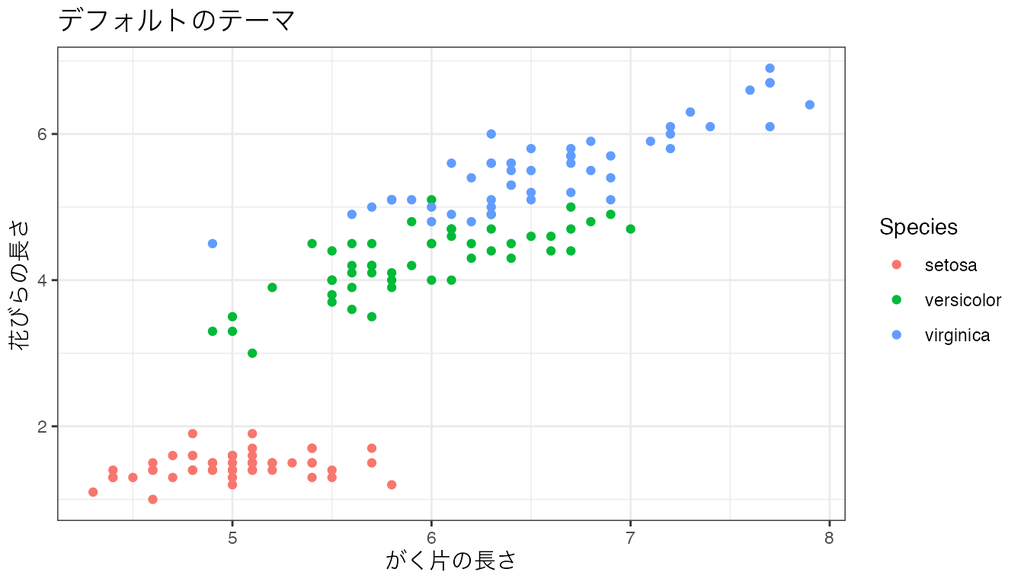

```r
p + theme_bw()      # 白黒テーマ（論文向き）
```

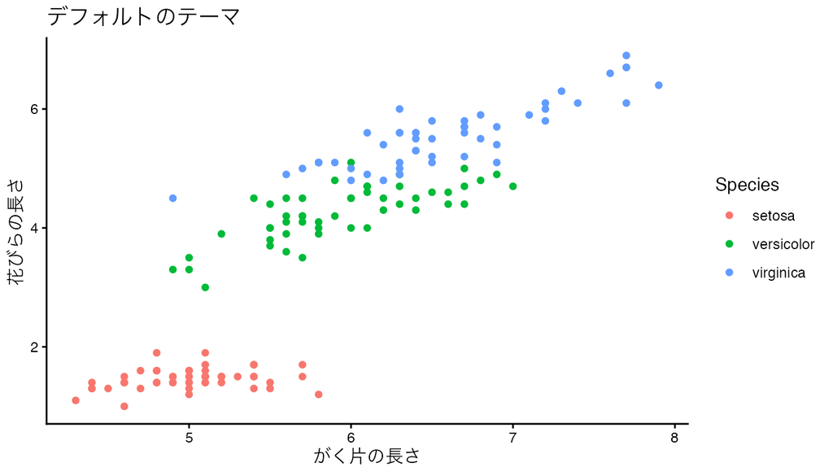

```r
p + theme_classic() # クラシック（軸線のみ，論文で人気）
```

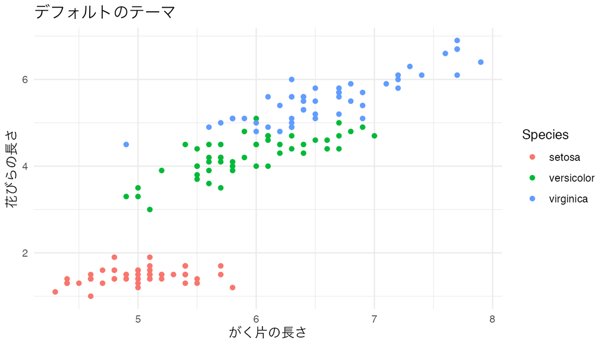

```r
p + theme_minimal() # ミニマル（シンプル）
```

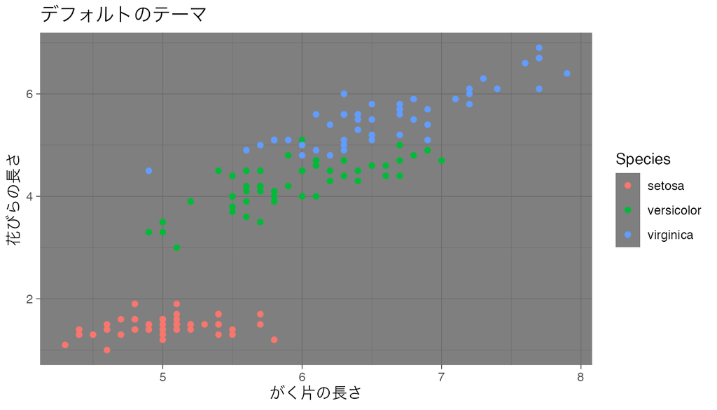

```r
p + theme_dark()    # ダーク（プレゼン向き）
```

> **論文・レポートには `theme_bw()` または `theme_classic()` がおすすめです。**

## 2. 色のカスタマイズ

### 手動で色を指定する

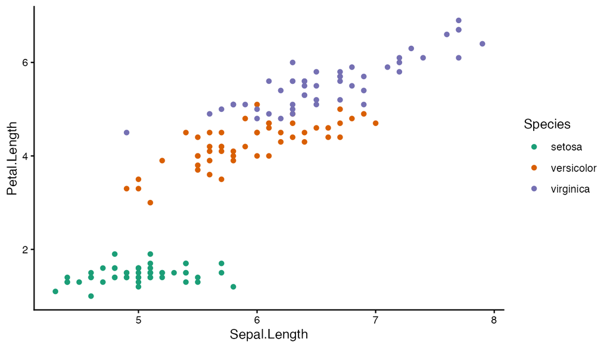

```r
ggplot(data = iris, aes(x = Sepal.Length, y = Petal.Length, color = Species)) +
  geom_point() +
  # 色は自分で決められます。ここでは Dark2 パレットの3色を書き出しました
  scale_color_manual(values = c("setosa" = "#1B9E77",
                                 "versicolor" = "#D95F02",
                                 "virginica" = "#7570B3")) +
  theme_classic()
```

### 組み込みのカラーパレット

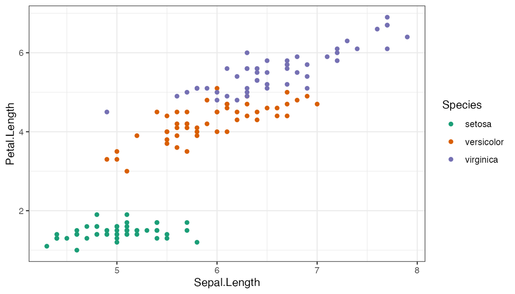

```r
# ColorBrewerパレット（カテゴリ変数向き）
ggplot(data = iris, aes(x = Sepal.Length, y = Petal.Length, color = Species)) +
  geom_point() +
  scale_color_brewer(palette = "Dark2") +
  theme_bw()
```

> **`"Dark2"` 以外に何があるか，どこで調べるか**

> パレットの名前は `RColorBrewer` というパッケージが持っています （`tidyverse` を入れると一緒に入るので，追加のインストールは要りません）。 **一覧を図で見る**には，コンソールで次を実行してください。

> ```r
> RColorBrewer::display.brewer.all()
> ```

> 3つのグループに分かれて表示されます。**種・性別のように順序のないもの**に使うのは **qual**（qualitative＝質的）のグループで，次の8つです。

> `Accent` `Dark2` `Paired` `Pastel1` `Pastel2` `Set1` `Set2` `Set3`

> 残りは，順序のある量に使う **seq**（薄い→濃い）と， 中央を基準に両側へ分かれる **div**（例：マイナス←0→プラス）です。 名前と使える色数を表で見たいときは `RColorBrewer::brewer.pal.info`， 関数の説明は `?scale_color_brewer` で読めます。

> **色数の上限があります。** 例えば `Set2` は8色までなので， 9つ以上のグループを塗り分けようとすると色が足りなくなります。 `iris` は3種なのでどれを選んでも足ります。

> **色の選び方には，好み以外の基準もあります**

> **この授業の資料では `Dark2` と `Set2` を使っています。** 色の見え方は人によって違い， 日本では男性の約5%に，赤と緑が近い色に見える型があります。 `Set1` や `Pastel1`（よく見かける既定のパレットです）はこの点で配慮されておらず， **赤と緑を隣り合わせに使うと，一部の人には同じ色に見えます。**

> 配慮されたパレットだけを表示するには次のようにします。

> ```r
> RColorBrewer::display.brewer.all(colorblindFriendly = TRUE)
> ```

> カテゴリ変数向き（qual）で配慮されているのは **`Dark2`・`Set2`・`Paired`** の3つだけです。 発表や論文に使う図では，ここから選んでください。 色のほかに**形（`shape =`）や線の種類（`linetype =`）も変える**と， 白黒で印刷されても読めます。

## 3. 軸・凡例のカスタマイズ

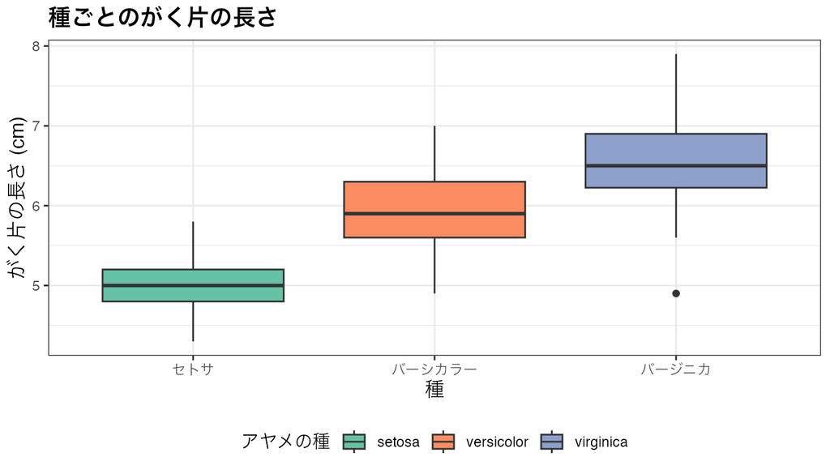

```r
ggplot(data = iris, aes(x = Species, y = Sepal.Length, fill = Species)) +
  geom_boxplot() +
  scale_x_discrete(labels = c("setosa" = "セトサ",
                               "versicolor" = "バーシカラー",
                               "virginica" = "バージニカ")) +
  scale_fill_brewer(palette = "Set2") +
  labs(
    title = "種ごとのがく片の長さ",
    x = "種",
    y = "がく片の長さ (cm)",
    fill = "アヤメの種"
  ) +
  theme_bw() +
  theme(
    legend.position = "bottom",        # 凡例の位置
    plot.title = element_text(size = 14, face = "bold"),  # タイトルの書式
    axis.title = element_text(size = 12)                  # 軸タイトルの書式
  )
```

## 4. 複数グラフを並べる（facet）

`facet_wrap()` で，指定した変数の**水準ごと**にグラフを分割できます。 ここでは `Species` という1つの変数の3水準（setosa / versicolor / virginica）で分かれます。

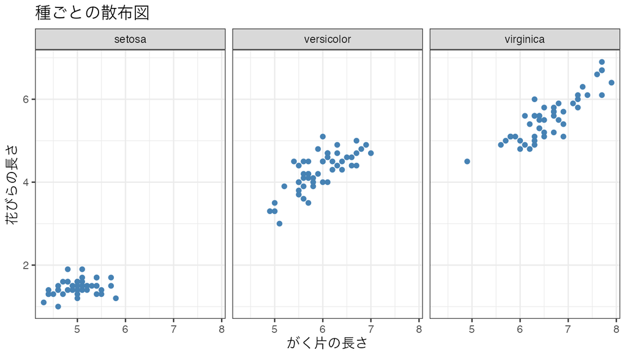

```r
ggplot(data = iris, aes(x = Sepal.Length, y = Petal.Length)) +
  geom_point(color = "steelblue") +
  facet_wrap(~ Species) +
  labs(title = "種ごとの散布図", x = "がく片の長さ", y = "花びらの長さ") +
  theme_bw()
```

## 5. 回帰直線を追加する

点の散らばりに**傾向を表す線**を重ねると，関係の向きが見やすくなります。

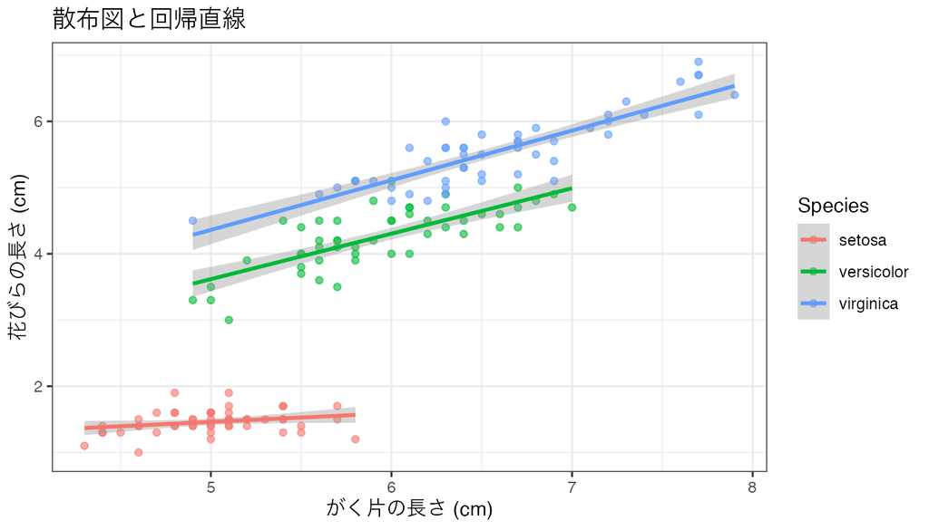

```r
ggplot(data = iris, aes(x = Sepal.Length, y = Petal.Length, color = Species)) +
  geom_point(alpha = 0.6) +
  geom_smooth(method = "lm", se = TRUE) +   # 回帰直線 + 信頼区間
  labs(title = "散布図と回帰直線",
       x = "がく片の長さ (cm)", y = "花びらの長さ (cm)") +
  theme_bw()
```

### 線が3本あるのはなぜか

`aes()` の中に `color = Species` があるので，**種ごとに別々の線**が引かれます。全体で1本ではありません。

3本をよく見ると，**傾きがそれぞれ違います。**

| 種 | 線の様子 |
| --- | --- |
| setosa | ほぼ横ばい。がく片が長くても，花びらの長さはあまり変わらない |
| versicolor | 右上がり |
| virginica | はっきり右上がり |

### グループを分けないとどう見えるか

`color = Species` を外すと，全体で1本になります。並べて見てください。

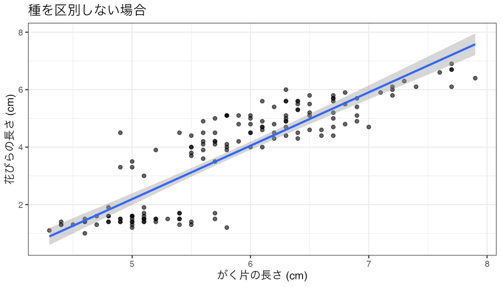

```r
ggplot(data = iris, aes(x = Sepal.Length, y = Petal.Length)) +
  geom_point(alpha = 0.6) +
  geom_smooth(method = "lm", se = TRUE) +
  labs(title = "種を区別しない場合", x = "がく片の長さ (cm)", y = "花びらの長さ (cm)") +
  theme_bw()
```

**1本にすると，3本のどれよりも急な線になります。**

傾きを並べると違いがはっきりします。

| 対象 | 傾き | 相関係数 $r$ |
| --- | --- | --- |
| 全体（1本） | 1.86 | 0.87 |
| setosa | 0.13 | 0.27 |
| versicolor | 0.69 | 0.75 |
| virginica | 0.75 | 0.86 |

全体の線が急になるのは，**setosaが左下に，virginicaが右上にかたまっている**ためです。 全体の傾向には，**同じ種の中での関係**と，**種どうしの平均的な大きさの違い**の両方が入っています。

> **全体に強い関係があること自体は確かです**（$r = 0.87$）。 問題になるのは，**その線をそのまま「同じ種の中での関係」として読むこと**です。 setosa の中では，がく片が長くても花びらの長さはほとんど変わりません（傾き0.13）。 **全体の傾向と，グループ内の傾向は分けて確かめてください。**

> **傾きの大きさと関係の強さは別のものです。** 全体（傾き1.86・$r$ = 0.87）と virginica（傾き0.75・$r$ = 0.86）を比べると， 傾きは2倍以上違うのに相関係数はほぼ同じです。 傾きは，**xが1増えたときに回帰直線上のyの予測値がどれだけ変わるか**を表します（単位はyの単位です）。 相関係数は，**2つの変数の直線的な関係の向きと強さ**を，単位によらない $-1$ から $1$ までの値で表します。

### この線と帯は何か

> **線**は，点の散らばりの真ん中あたりを通るように引いた直線です（**回帰直線**といいます）。 **影の帯**は，各xにおける**平均的なyの値をどれくらい確かに推定できるか**を表す95%信頼区間です。 直線を当てはめた今回は，**xの平均のあたりで最も狭く，そこから離れるほど広がります**。 全体で1本引いた図では，がく片の長さの全体平均5.84 cm付近で最も狭くなります。 種ごとに線を引いた図では，**それぞれの種の平均付近**で最も狭くなります （種ごとの線は，その種のデータだけを使って別々に当てはめられています）。 「データの95%がこの帯に入る」という意味ではありません。 帯が不要なら `se = FALSE` と書きます。

> 計算の中身と解釈のしかたは**第8回以降**で扱います。今日は「傾向を目で見るための補助線」として使います。

> **線が引けたからといって，原因と結果の関係があるとは限りません。** 「がく片が長いから花びらが長くなる」とは言えません。どちらも「その種はもともと大きい」という 共通の理由で説明できるかもしれないからです。線は関係の**向き**を見せるだけです。

## 6. グラフの保存（ggsave）

作成したグラフをファイルに保存するには `ggsave()` を使います。

```r
# グラフを変数に保存しておく
my_plot <- ggplot(data = iris, aes(x = Species, y = Sepal.Length, fill = Species)) +
  geom_boxplot() +
  theme_bw() +
  labs(title = "種ごとのがく片の長さ")

# PNG形式で保存
ggsave(filename = "my_plot.png",
       plot = my_plot,
       width = 8,       # 幅（インチ）
       height = 5,      # 高さ（インチ）
       dpi = 300)       # 解像度（論文用は300以上推奨）

# PDF形式で保存（ベクター形式，高品質）
ggsave(filename = "my_plot.pdf",
       plot = my_plot,
       width = 8,
       height = 5)
```

> **ファイルはどこに保存されるか**

> パスを書かずにファイル名だけを指定すると，**いま作業しているフォルダ**に保存されます。 どこかは `getwd()` で確認できます。プロジェクトを使っていれば，プロジェクトのフォルダです。

> **日本語を含む図をPDFで保存するときの注意**

> PDFの標準フォントは日本語に対応していないため，環境によっては**文字が消えたり□になったり**します。 うまくいかないときは PNG で保存するか，次のように書いてください。

> ```r
> ggsave("my_plot.pdf", my_plot, width = 8, height = 5,
>        device = grDevices::cairo_pdf)
> ```

> `cairo_pdf` も環境によっては使えないことがあります。**確実なのはPNGです。**

### 解像度の目安

**これはPNGなどの画像形式（ラスター）の目安です。** PDFは点ではなく線の情報で保存するため， `dpi` を上げても仕上がりは変わりません。

| 用途 | dpi |
| --- | --- |
| 画面・Web表示 | 72〜96 |
| 印刷・プレゼン | 150〜200 |
| 論文投稿 | 300〜600 |

`width = 7`，`height = 5`，`dpi = 300` なら **2100 × 1500 ピクセル**のPNGになります （インチ数 × dpi）。論文に出すときは，投稿先の指定があればそちらを優先してください。

## 7. よく使うグラフのまとめ

| グラフの種類 | 用途 | geom関数 |
| --- | --- | --- |
| 散布図 | 2変数の関係 | `geom_point()` |
| ヒストグラム | 1変数の分布 | `geom_histogram()` |
| 棒グラフ | カテゴリのカウント・集計値 | `geom_bar()` / `geom_col()` |
| 箱ひげ図 | グループ間の分布比較 | `geom_boxplot()` |
| 折れ線グラフ | 時系列・連続変化 | `geom_line()` |
| バイオリン図 | 箱ひげ図より詳細な分布 | `geom_violin()` |

## 演習

### 演習1：テーマの比較

第3回で作ったグラフのいずれかに，`theme_classic()` と `theme_bw()` を適用し， どちらが見やすいか比較してください。

### 演習2：論文用グラフの作成

以下の要件を満たすグラフを作成してください。

- **データ**：`iris`
- **グラフの種類**：箱ひげ図
- **x軸**：Species，**y軸**：Petal.Length
- **色**：`fill = Species`，カラーパレットは `"Set2"`
- **テーマ**：`theme_bw()`
- **日本語のラベル**：タイトル・軸ラベルを日本語で
- **凡例の位置**：下（`legend.position = "bottom"`）

```r
ggplot(data = iris, aes(x = ___, y = ___, fill = ___)) +
  geom_boxplot() +
  scale_fill_brewer(palette = "___") +
  labs(title = "___", x = "___", y = "___") +
  theme_bw() +
  theme(legend.position = "___")
```

### 演習3：グラフの保存

演習2で作ったグラフを `kadai_02.png`（dpi = 300，幅 = 7インチ，高さ = 5インチ）で保存してください。

## 本日のまとめ

- `theme_bw()` / `theme_classic()` で論文向きのデザインにできる
- `scale_color_manual()` や `scale_color_brewer()` で色をカスタマイズ
- `facet_wrap()` で，指定した変数の水準ごとに分割したグラフを作れる
- **`geom_smooth(method = "lm")`** で回帰直線を追加できる（`method` を省略すると直線以外の曲線になる）
- `ggsave()` でグラフをPNG・PDFなどで保存できる

## 宿題・予習

- **演習3で保存した `kadai_02.png` を開いて，画像ができていることを確認する**
  - **提出は要りません。** 自分のパソコンに保存できていれば完了です
  - どこに保存されたか分からなくなったら `getwd()` で確認してください
  - 画像の大きさが **2100 × 1500 ピクセル**になっていれば，`dpi = 300` が効いています （Windows はファイルを右クリック →「プロパティ」→「詳細」， Mac は右クリック →「情報を見る」で確認できます）
- 次回から **データの加工（dplyr）** に入ります
- 教科書のdplyr関連の章に目を通しておく